# 02; Random Graph Models

Networks I: Concepts and Algorithms | BSE Data Science

Author

Notes based on Milán (2026), Newman (2013), Easley & Kleinberg (2010)

Published

March 19, 2026

# 1 The Case for Random Graph Models

## 1.1 From Description to Inference

In Lecture 1 we learned to *describe* networks: compute degree distributions, path lengths, clustering coefficients, centralities. These are useful summaries, but they leave open the most important question: **is what we observe surprising?**

Suppose we find that the American75 Facebook network has transitivity $C = 0.15$. Is that high or low? We cannot answer without a **baseline**; a reference distribution of what $C$ looks like in “generic” networks with the same basic parameters ($n$ nodes, $\langle k \rangle$ average degree).

This is the role of **random graph models**: they provide principled null distributions against which to measure real-world structure.

**NoteThree uses of random graph models**

1. **Null model testing**: is the clustering/modularity/diameter of my network significantly different from what a random graph would produce?
2. **Generative understanding**: what simple mechanisms give rise to the patterns we observe (power laws, small worlds, community structure)?
3. **Analytical tractability**: random graphs admit exact or asymptotic calculations that real networks do not.

## 1.2 A Roadmap of Models (and Their Failures)

We will introduce models in order of increasing realism, and crucially, each model’s *failure* motivates the next:

| Model | What it gets right | What it misses |
| --- | --- | --- |
| Erdős–Rényi $G(n,p)$ | Degree distribution tractable, phase transition | Clustering $\to 0$, Poisson tails |
| Configuration model | Arbitrary degree sequence | Clustering $\to 0$, no community structure |
| Watts–Strogatz | High clustering AND short paths | Degree distribution still Poisson-like |
| Barabási–Albert | Power-law degree distribution | No clustering, no communities |
| Jackson–Rogers hybrid | Power law + positive clustering | Computationally heavier |
| Stochastic Block Model | Community structure | Assumes homogeneous within-community degree |
| DC-SBM | Community structure + degree heterogeneity | More parameters |

# 2 Erdős–Rényi: The Simplest Random Graph

## 2.1 Model Definition

The **Erdős–Rényi model** $G(n, p)$ (Gilbert 1959; Erdős & Rényi 1959–60) is the simplest possible random graph: each of the $\binom{n}{2}$ potential edges exists independently with probability $p$.

The adjacency matrix entries are i.i.d. Bernoulli:

$$A_{ij} = A_{ji} \sim \text{Bernoulli}(p) \quad \forall i < j$$

The probability of drawing a particular graph with $m$ edges is:

$$\Pr(G) = p^m (1-p)^{\binom{n}{2} - m}$$

The **G(n, m)** variant fixes the *number* of edges at exactly $m$, choosing uniformly among all graphs with that edge count. As we will see (PS1 Q3), the two models are equivalent for large $n$ when $m = \langle m \rangle$.

## 2.2 Expected Properties

**Expected degree**: each node can link to $n-1$ others, each with probability $p$:
$$\langle k \rangle = (n-1)p$$

**Expected edges**: $\langle m \rangle = \binom{n}{2} p = \frac{n(n-1)}{2} p$

To study “interesting” limiting behaviour we want $\langle k \rangle = c$ fixed as $n \to \infty$. This requires $p = c/(n-1) \to 0$, so the graph becomes *sparser* as it grows.

## 2.3 Degree Distribution: From Binomial to Poisson

Each node independently connects to each of the other $n-1$ nodes with probability $p$, so degree follows a Binomial:

$$\Pr(k) = \binom{n-1}{k} p^k (1-p)^{n-1-k}$$

For $p = c/(n-1)$ and $n \to \infty$, this converges to a **Poisson** distribution:

$$\Pr(k) \approx \frac{c^k}{k!} e^{-c}$$

The derivation uses $\binom{n-1}{k} p^k \approx c^k/k!$ and $(1-p)^{n-1-k} \approx e^{-c}$ for large $n$. Both mean and variance of this Poisson are equal to $c$.

## 2.4 Clustering: A Critical Failure

The global clustering coefficient in $G(n,p)$ is simply:

$$C = \frac{\text{triangles} \times 3}{\text{connected triples}} \approx \frac{\binom{n}{3} p^3}{\binom{n}{3} p^2} = p = \frac{c}{n-1}$$

As $n \to \infty$ with $c$ fixed: $C \to 0$. ER graphs are **locally tree-like**: there are essentially no triangles, and no cycles of any finite length, in the large-$n$ limit.

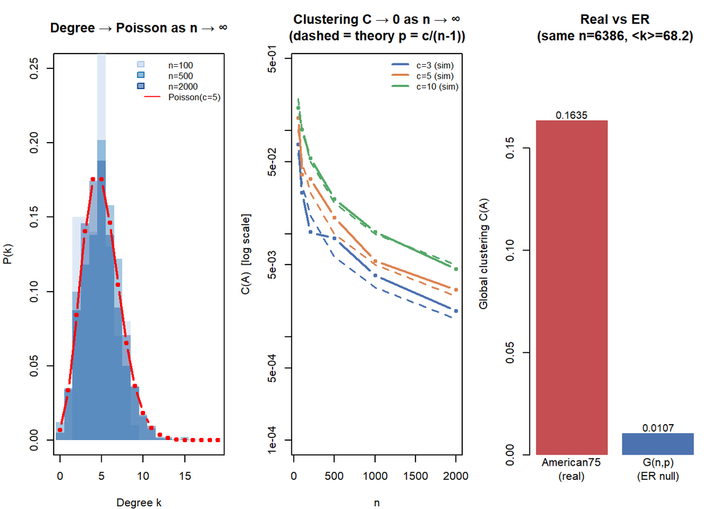

Degree distribution of G(n,p) approaches Poisson as n grows. Clustering vanishes.

```r
set.seed(42)
c_target <- 5.0

## (A) Degree distribution: simulated vs Poisson theory
par(mfrow = c(1, 3), mar = c(4, 4, 4, 1))

# Overlapping histograms for n = 100, 500, 2000
all_n     <- c(100, 500, 2000)
all_cols  <- c("#aec7e8", "#1f77b4", "#084594")
k_range   <- 0:19

# Build density matrices for plotting
plot(NULL, xlim = c(0, 19), ylim = c(0, 0.25),
     xlab = "Degree k", ylab = "P(k)",
     main = "Degree → Poisson as n → ∞")
for (i in seq_along(all_n)) {
  n   <- all_n[i]
  p   <- c_target / (n - 1)
  g_t <- erdos.renyi.game(n = n, p = p, type = "gnp")
  d   <- degree(g_t)
  # Use hist with add=TRUE trick via density
  h <- hist(d, breaks = -1:20 + 0.5, plot = FALSE)
  rect(h$breaks[-length(h$breaks)], 0, h$breaks[-1], h$density,
       col = adjustcolor(all_cols[i], alpha.f = 0.4), border = NA)
}
lines(k_range, dpois(k_range, lambda = c_target),
      col = "red", lwd = 2, type = "b", pch = 19, cex = 0.6)
legend("topright", legend = c("n=100", "n=500", "n=2000",
                               paste0("Poisson(c=", c_target, ")")),
       fill   = c(adjustcolor(all_cols, 0.5), NA),
       lty    = c(NA, NA, NA, 1), col = c(NA, NA, NA, "red"),
       border = c(all_cols, NA), bty = "n", cex = 0.8)

## (B) Clustering vs n (log-y scale)
ns      <- c(50, 100, 200, 500, 1000, 2000)
c_vals  <- c(3, 5, 10)
col_b   <- c("#4C72B0", "#DD8452", "#55A868")

plot(NULL, xlim = range(ns), ylim = c(1e-4, 0.4),
     log  = "y",
     xlab = "n", ylab = "C(A)  [log scale]",
     main = "Clustering C → 0 as n → ∞\n(dashed = theory p = c/(n-1))")
for (j in seq_along(c_vals)) {
  c_v      <- c_vals[j]
  obs_C    <- numeric(length(ns))
  er_pred  <- numeric(length(ns))
  for (i in seq_along(ns)) {
    n <- ns[i]
    p <- c_v / (n - 1)
    g_t      <- erdos.renyi.game(n = n, p = p, type = "gnp")
    obs_C[i] <- transitivity(g_t, type = "global")
    er_pred[i] <- p
  }
  lines(ns, obs_C,   col = col_b[j], lwd = 2, type = "b", pch = 19, cex = 0.5)
  lines(ns, er_pred, col = col_b[j], lwd = 1.5, lty = 2)
}
legend("topright", legend = paste0("c=", c_vals, " (sim)"),
       col = col_b, lwd = 2, bty = "n", cex = 0.8)

## (C) Real Facebook vs ER null
mat  <- readMat("American75.mat")
A_sp <- mat$A
A_t  <- as(A_sp, "TsparseMatrix")
edges_fb <- cbind(A_t@i + 1L, A_t@j + 1L)
g_fb     <- graph_from_edgelist(edges_fb, directed = FALSE)
g_fb     <- simplify(g_fb)

n_fb <- vcount(g_fb)
c_fb <- mean(degree(g_fb))
p_fb <- c_fb / (n_fb - 1)
g_er_fb  <- erdos.renyi.game(n = n_fb, p = p_fb, type = "gnp")

C_real <- transitivity(g_fb,    type = "global")
C_er   <- transitivity(g_er_fb, type = "global")
labels <- c("American75\n(real)", "G(n,p)\n(ER null)")
C_vals_bar <- c(C_real, C_er)
bar_cols   <- c("#C44E52", "#4C72B0")

bp <- barplot(C_vals_bar, names.arg = labels, col = bar_cols, border = NA,
              ylab = "Global clustering C(A)",
              main = sprintf("Real vs ER\n(same n=%d, <k>=%.1f)", n_fb, c_fb),
              ylim = c(0, max(C_vals_bar) * 1.2))
text(bp, C_vals_bar + 0.003, sprintf("%.4f", C_vals_bar),
     cex = 0.9, adj = 0.5)
```

```r
cat(sprintf("American75: C = %.4f\n", C_real))
```

```
American75: C = 0.1635
```

```r
cat(sprintf("ER null:    C = %.5f\n", C_er))
```

```
ER null:    C = 0.01071
```

```r
cat(sprintf("Ratio (real/ER): %.0fx higher\n", C_real / C_er))
```

```
Ratio (real/ER): 15x higher
```

## 2.5 Phase Transitions and the Giant Component

### 2.5.1 The Phase Transition Phenomenon

Perhaps the most beautiful result in random graph theory is the sudden emergence of a **giant component**; a connected component containing a finite fraction of all nodes; as the average degree $c$ crosses 1.

**ImportantErdős–Rényi Phase Transition**

At $c = \langle k \rangle = 1$, there is a sharp phase transition:

- **Subcritical** ($c < 1$): all components have size $O(\log n)$. The largest component as a fraction of $n$ vanishes.
- **Supercritical** ($c > 1$): a **giant component** of size $\sim Sn$ exists, where $S > 0$ solves $S = 1 - e^{-cS}$.
- **Critical** ($c = 1$): largest component is $O(n^{2/3})$; diverging, but sub-linear in $n$.

### 2.5.2 Deriving the Giant Component Equation

Let $u$ be the probability that a randomly chosen node is *not* in the giant component. Node $i$ is not in the GC if, for every other node $j$, *either* there is no edge $(i,j)$ (probability $1-p$) *or* there is an edge but $j$ is not in the GC (probability $pu$). Since edges are independent:

$$u = (1 - p + pu)^{n-1}$$

Substituting $p = c/(n-1)$ and taking logs:

$$\ln u = (n-1) \ln\!\left(1 - \frac{c(1-u)}{n-1}\right) \approx -(n-1) \cdot \frac{c(1-u)}{n-1} = -c(1-u)$$

Letting $S = 1 - u$ (the fraction *in* the GC):

$$\boxed{S = 1 - e^{-cS}}$$

This transcendental equation has no closed-form solution, but we can solve it graphically or numerically. For $c \leq 1$: the only solution is $S = 0$. For $c > 1$: a unique positive solution $S \in (0, 1)$ exists.

### 2.5.3 Full Connectivity

Once the giant component absorbs almost all nodes, we can ask: when does the *entire* network become connected (no isolated nodes)?

An isolated node survives if all $n-1$ potential neighbours are absent. The expected number of isolated nodes is:

$$I_n = n(1-p)^{n-1} \approx n e^{-np} \approx n e^{-c}$$

For the last isolated node to disappear ($I_n = 1$), we need $p \sim \ln(n)/n$, corresponding to $c = \langle k \rangle \sim \ln n$.

**Summary of phase transitions**:

| $p$ (order) | Event |
| --- | --- |
| $1/n^2$ | First edge appears |
| $1/n^{3/2}$ | First triple (path of length 2) |
| $1/n$ | Giant component emerges ($c = 1$) |
| $\ln n / n$ | Graph becomes fully connected |

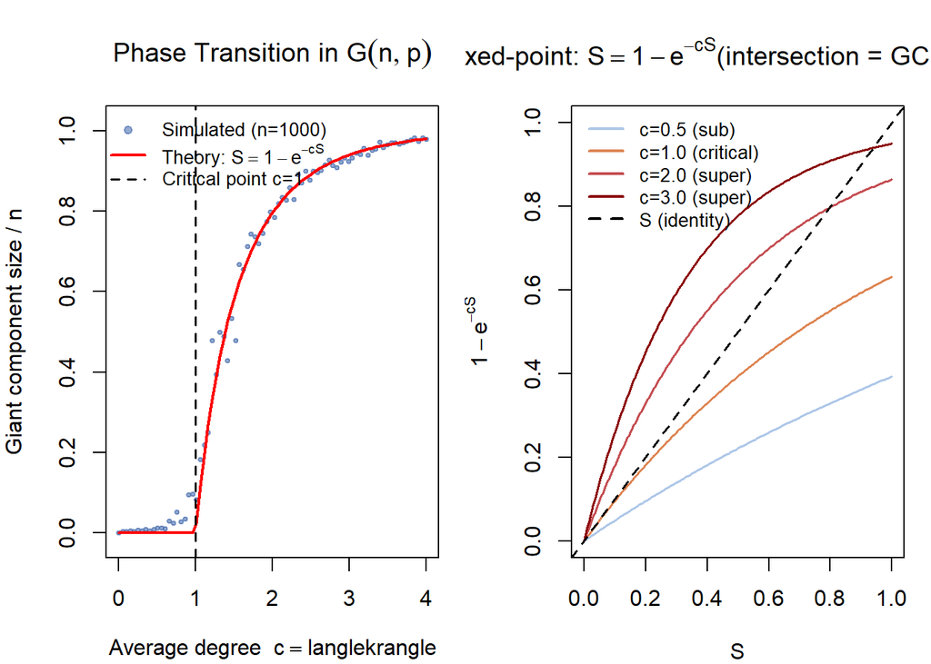

Phase transition in G(n,p). The giant component jumps from 0 to O(n) at c=1.

```r
## Theoretical S via bisection
gc_theory <- function(c) {
  if (c <= 1) return(0.0)
  f <- function(S) S - (1 - exp(-c * S))
  uniroot(f, c(1e-9, 1 - 1e-9))$root
}

set.seed(42)
n       <- 1000
c_range <- seq(0, 4, length.out = 80)

gc_frac_sim <- sapply(c_range, function(c) {
  p     <- c / (n - 1)
  g_tmp <- erdos.renyi.game(n = n, p = p, type = "gnp")
  max(components(g_tmp)$csize) / n
})

S_theory <- sapply(c_range, gc_theory)

par(mfrow = c(1, 2), mar = c(4, 4, 4, 1))

## (A) Simulated vs theory
plot(c_range, gc_frac_sim,
     pch = 19, cex = 0.5, col = adjustcolor("#4C72B0", 0.6),
     xlab = expression(paste("Average degree  ", c == langle*k*rangle)),
     ylab = "Giant component size / n",
     main = expression(paste("Phase Transition in ", G(n, p))),
     ylim = c(-0.02, 1.02))
lines(c_range, S_theory, col = "red", lwd = 2)
abline(v = 1, lty = 2, lwd = 1.5, col = "black")
legend("topleft",
       legend = c(paste0("Simulated (n=", n, ")"),
                  expression(paste("Theory: ", S == 1 - e^{-cS})),
                  "Critical point c=1"),
       col    = c(adjustcolor("#4C72B0", 0.6), "red", "black"),
       pch    = c(19, NA, NA), lty = c(NA, 1, 2), lwd = c(NA, 2, 1.5),
       bty    = "n", cex = 0.85)

## (B) Fixed-point geometry
S_vals <- seq(0, 1, length.out = 200)
c_fp   <- c(0.5, 1.0, 2.0, 3.0)
fp_cols <- c("#aec7e8", "#DD8452", "#C44E52", "#8B0000")
fp_labs <- c("c=0.5 (sub)", "c=1.0 (critical)", "c=2.0 (super)", "c=3.0 (super)")

plot(NULL, xlim = c(0, 1), ylim = c(0, 1),
     xlab = "S", ylab = expression(1 - e^{-cS}),
     main = expression(paste("Fixed-point: ", S == 1 - e^{-cS},
                             "\n(intersection = GC fraction)")))
for (j in seq_along(c_fp)) {
  lines(S_vals, 1 - exp(-c_fp[j] * S_vals),
        col = fp_cols[j], lwd = 1.8)
}
abline(0, 1, lty = 2, lwd = 1.5)
legend("topleft", legend = c(fp_labs, "S (identity)"),
       col = c(fp_cols, "black"), lwd = 2,
       lty = c(rep(1, 4), 2), bty = "n", cex = 0.85)
```

```r
## Print GC fractions at key c values
for (c_v in c(0.5, 0.9, 1.0, 1.5, 2.0, 3.0)) {
  S <- gc_theory(c_v)
  diam_log <- log(1000) / log(max(c_v, 1.001))
  cat(sprintf("c = %.1f:  theory S = %.4f,  diameter ≈ ln(n)/ln(c) = %.1f\n",
              c_v, S, diam_log))
}
```

```
c = 0.5:  theory S = 0.0000,  diameter ≈ ln(n)/ln(c) = 6911.2
c = 0.9:  theory S = 0.0000,  diameter ≈ ln(n)/ln(c) = 6911.2
c = 1.0:  theory S = 0.0000,  diameter ≈ ln(n)/ln(c) = 6911.2
c = 1.5:  theory S = 0.5828,  diameter ≈ ln(n)/ln(c) = 17.0
c = 2.0:  theory S = 0.7968,  diameter ≈ ln(n)/ln(c) = 10.0
c = 3.0:  theory S = 0.9405,  diameter ≈ ln(n)/ln(c) = 6.3
```

### 2.5.4 Contagion on ER Graphs (Application)

The phase transition directly models **epidemic thresholds**. Consider an SI (susceptible-infected) model on $G(n,p)$:

- A fraction $\pi$ of nodes are vaccinated (immune)
- Effective graph: $G((1-\pi)n, p)$; remove immune nodes
- The disease spreads iff this effective graph has a giant component

The epidemic threshold is when the effective average degree exceeds 1: $c_{\text{eff}} = (1-\pi) c > 1$, i.e., $\pi < 1 - 1/c$.

This is the **herd immunity threshold** in network terms. For the network to be protected, we must vaccinate at least fraction $1 - 1/c$ of nodes.

# 3 The Configuration Model: Arbitrary Degree Sequences

## 3.1 Why We Need More Than ER

Erdős–Rényi produces Poisson degree distributions. Real networks have heavy-tailed degree distributions; power laws, log-normals. The **configuration model** decouples the degree sequence from the wiring pattern: we can input *any* degree sequence $\{k_1, k_2, \ldots, k_n\}$ and get a “random” graph that has those exact degrees.

The construction (Bender & Canfield 1978):

1. Give node $i$ exactly $k_i$ **stubs** (half-edges)
2. Choose a uniformly random perfect matching of all $\sum_i k_i$ stubs
3. Each matched pair of stubs becomes an edge

This produces multi-edges and self-loops with probability $O(1/n)$, which vanishes in large networks. For our purposes, we treat the resulting graph as simple.

## 3.2 Key Properties

**Linking probability** between nodes $i$ and $j$:
$$p_{ij} = \frac{k_i k_j}{\sum_l k_l} = \frac{k_i k_j}{2m}$$

This is a *heterogeneous* ER model: high-degree nodes are more likely to connect to each other; and to everyone else.

**Expected number of common neighbours** between $i$ and $j$:
$$N_{ij} = \sum_l p_{il} p_{lj} = \frac{k_i k_j}{2m} \cdot \frac{\langle k^2 \rangle - \langle k \rangle}{\langle k \rangle}$$

**Clustering still vanishes**: $C = O(1/n)$ for fixed $\langle k \rangle$, just as in ER. The configuration model fixes the *degree sequence* but still wires edges randomly; no triangle-formation mechanism exists.

## 3.3 The Friendship Paradox

One of the most surprising properties of configuration models:

**ImportantFriendship Paradox (Feld 1991)**

**On average, your friends have more friends than you do.**

Formally, the expected degree of a *uniformly chosen neighbour* is:

$$\langle k_{\text{nbr}} \rangle = \frac{\langle k^2 \rangle}{\langle k \rangle} = \langle k \rangle + \frac{\text{Var}(k)}{\langle k \rangle} \geq \langle k \rangle$$

with equality only when all degrees are equal.

*Why*: when you follow a random edge, the probability of landing at node $j$ is proportional to $k_j$ (high-degree nodes contribute more stubs, so are more likely to be at the other end of a randomly chosen edge). This *size-biased sampling* over-represents hubs.

**Economic consequences** (Jackson 2019, JPE): the friendship paradox creates *systematic misperceptions*. If your friends are on average richer, healthier, or better-connected than you, you may mis-calibrate social norms and make suboptimal choices. Jackson shows this can cascade into information avalanches: even though only 1/3 of the population genuinely prefers choice A, biased sampling through social networks can make it look like the unanimous favourite.

**Giant component in the configuration model**: emerges when $\langle k^2 \rangle - 2\langle k \rangle > 0$. For a Poisson distribution ($\langle k^2 \rangle = \langle k \rangle^2 + \langle k \rangle$), this reduces to $\langle k \rangle > 1$; recovering the ER result. For heavy-tailed distributions, the condition is weaker: networks with power-law degree distributions essentially always have a giant component.

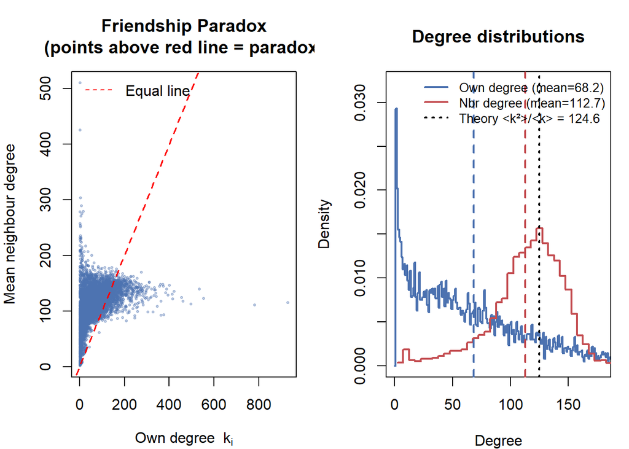

Friendship paradox: your neighbours’ average degree exceeds your own.

```r
## Load American75 (re-use g_fb from earlier chunk, or reload)
mat      <- readMat("American75.mat")
A_sp     <- mat$A
A_t      <- as(A_sp, "TsparseMatrix")
edges_fb <- cbind(A_t@i + 1L, A_t@j + 1L)
g_real   <- graph_from_edgelist(edges_fb, directed = FALSE)
g_real   <- simplify(g_real)

degrees  <- degree(g_real)
n_nodes  <- vcount(g_real)

# Mean degree of each node's neighbourhood
nbr_mean_k <- sapply(seq_len(n_nodes), function(v) {
  nbrs <- neighbors(g_real, v)
  if (length(nbrs) == 0) return(0.0)
  mean(degrees[nbrs])
})

mean_k    <- mean(degrees)
mean_k2   <- mean(degrees^2)
theory_nbr <- mean_k2 / mean_k

mask <- degrees >= 2

par(mfrow = c(1, 2), mar = c(4, 4, 4, 1))

## (A) Scatter: own degree vs mean neighbour degree
plot(degrees[mask], nbr_mean_k[mask],
     pch = 19, cex = 0.4, col = adjustcolor("#4C72B0", 0.3),
     xlab = expression(paste("Own degree  ", k[i])),
     ylab = "Mean neighbour degree",
     main = "Friendship Paradox\n(points above red line = paradox)")
abline(0, 1, col = "red", lty = 2, lwd = 1.5)
legend("topleft", legend = "Equal line", col = "red", lty = 2, bty = "n")

## (B) Distribution comparison
max_deg <- max(degrees)
h_own <- hist(degrees,           breaks = seq(-0.5, max_deg + 0.5, 1),
              plot = FALSE)
h_nbr <- hist(nbr_mean_k[mask],  breaks = seq(0, max(nbr_mean_k[mask]) + 5, 5),
              plot = FALSE)

plot(h_own$mids, h_own$density, type = "s", col = "#4C72B0", lwd = 2,
     xlab = "Degree", ylab = "Density",
     main = "Degree distributions",
     xlim = c(0, quantile(nbr_mean_k[mask], 0.99)),
     ylim = c(0, max(h_own$density) * 1.1))
lines(h_nbr$mids, h_nbr$density, type = "s", col = "#C44E52", lwd = 2)
abline(v = mean_k,               col = "#4C72B0", lty = 2, lwd = 2)
abline(v = mean(nbr_mean_k[mask]),col = "#C44E52", lty = 2, lwd = 2)
abline(v = theory_nbr,            col = "black",   lty = 3, lwd = 2)
legend("topright",
       legend = c(sprintf("Own degree (mean=%.1f)", mean_k),
                  sprintf("Nbr degree (mean=%.1f)", mean(nbr_mean_k[mask])),
                  sprintf("Theory <k²>/<k> = %.1f", theory_nbr)),
       col = c("#4C72B0", "#C44E52", "black"),
       lwd = 2, lty = c(1, 1, 3), bty = "n", cex = 0.85)
```

```r
cat(sprintf("Own mean degree:          <k>   = %.2f\n", mean_k))
```

```
Own mean degree:          <k>   = 68.17
```

```r
cat(sprintf("Mean neighbour's degree:        = %.2f\n", mean(nbr_mean_k[mask])))
```

```
Mean neighbour's degree:        = 112.72
```

```r
cat(sprintf("Theory <k²>/<k>:               = %.2f\n", theory_nbr))
```

```
Theory <k²>/<k>:               = 124.63
```

```r
cat(sprintf("Var(k)/<k> (excess):            = %.2f\n",
            mean_k2 / mean_k - mean_k))
```

```
Var(k)/<k> (excess):            = 56.46
```

```r
cat(sprintf("\nFriendship paradox ratio: %.2fx\n",
            mean(nbr_mean_k[mask]) / mean_k))
```

```
Friendship paradox ratio: 1.65x
```

# 4 The Watts–Strogatz Small World Model

## 4.1 The Core Tension

We have two stylised facts about real social networks:

1. **High clustering**: people in the same community know each other ($C \sim 0.1$–$0.5$).
2. **Short average path lengths**: “six degrees of separation” suggests $\langle \ell \rangle = O(\log n)$.

These seem contradictory. High clustering requires lots of local triangles; which means most of your edges connect to people already in your cluster. Short paths require long-range connections that skip across the network. How can both hold simultaneously?

Erdős–Rényi achieves short paths (random wiring is great for connectivity) but kills clustering. Can we do better?

## 4.2 The Model

Watts & Strogatz (1998) propose a one-parameter interpolation:

1. **Start** with a regular ring lattice: $n$ nodes arranged in a circle, each connected to its $k$ nearest neighbours (so each node has degree $k$). This has high clustering and $O(n/k)$ diameter.
2. **Rewire** each edge independently with probability $\beta$: one endpoint is kept, the other is replaced with a uniformly random node.

At $\beta = 0$: original lattice; high $C$, large $\langle \ell \rangle$. At $\beta = 1$: Erdős–Rényi; low $C$, small $\langle \ell \rangle$.

**The key insight**: a *small number* of rewirings (small $\beta > 0$) dramatically collapses path lengths while leaving clustering nearly intact. This is because one “shortcut” across the network can reduce distances between two entire clusters from $O(n)$ to $O(1)$.

**Clustering of the lattice** (exact formula for even $k$):
$$C_{\text{lattice}} = \frac{3(k-2)}{4(k-1)} \approx \frac{3}{4} \quad (k \gg 1)$$

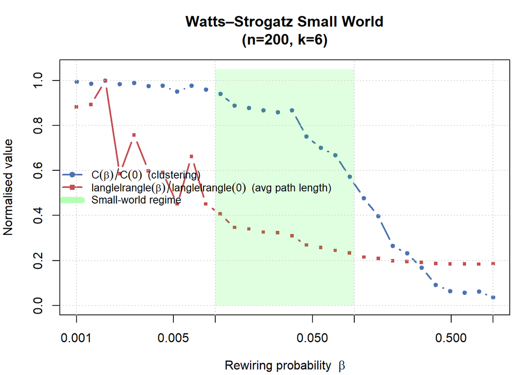

Watts–Strogatz: clustering stays high while diameter collapses for small β.

```r
set.seed(42)
n_ws  <- 200
k_ws  <- 6   # each node connects to k_ws nearest neighbours

# Baseline lattice (beta = 0)
g0 <- sample_smallworld(dim = 1, size = n_ws, nei = k_ws / 2, p = 0)
C0 <- transitivity(g0, type = "global")
L0 <- mean_distance(g0, directed = FALSE)

betas  <- 10^seq(-3, 0, length.out = 30)
C_norm <- numeric(length(betas))
L_norm <- numeric(length(betas))

for (i in seq_along(betas)) {
  g_ws      <- sample_smallworld(dim = 1, size = n_ws, nei = k_ws / 2, p = betas[i])
  C_norm[i] <- transitivity(g_ws, type = "global") / C0
  L_norm[i] <- mean_distance(g_ws, directed = FALSE) / L0
}

par(mar = c(4, 4, 4, 1))
plot(betas, C_norm,
     log  = "x", type = "b", pch = 19, cex = 0.6,
     col  = "#4C72B0", lwd = 2,
     xlab = expression(paste("Rewiring probability  ", beta)),
     ylab = "Normalised value",
     main = sprintf("Watts–Strogatz Small World\n(n=%d, k=%d)", n_ws, k_ws),
     ylim = c(0, 1.05))
lines(betas, L_norm, type = "b", pch = 15, cex = 0.6,
      col = "#C44E52", lwd = 2)
# Shade small-world regime
rect(1e-2, 0, 0.1, 1.05,
     col = adjustcolor("green", alpha.f = 0.12), border = NA)
legend("left",
       legend = c(expression(C(beta)/C(0)~~"(clustering)"),
                  expression(langle*l*rangle(beta)/langle*l*rangle(0)~~"(avg path length)"),
                  "Small-world regime"),
       col    = c("#4C72B0", "#C44E52", adjustcolor("green", 0.3)),
       lwd    = c(2, 2, 8), pch = c(19, 15, NA), bty = "n", cex = 0.85)
grid()
```

```r
cat(sprintf("At β = 0 (lattice): C = %.3f  L = %.2f\n", C0, L0))
```

```
At β = 0 (lattice): C = 0.600  L = 17.09
```

```r
idx_half_L <- which(L_norm < 0.5)[1]
cat(sprintf("At β ≈ %.4f: L drops to 50%% of L0, C still at %.0f%% of C0\n",
            betas[idx_half_L], 100 * C_norm[idx_half_L]))
```

```
At β ≈ 0.0053: L drops to 50% of L0, C still at 95% of C0
```

```r
g_rnd <- sample_gnm(n = n_ws,
                    m = n_ws * k_ws / 2)
cat(sprintf("At β = 1 (ER approx): C = %.3f  L = %.2f\n",
            transitivity(g_rnd, type = "global"),
            mean_distance(g_rnd, directed = FALSE)))
```

```
At β = 1 (ER approx): C = 0.036  L = 3.14
```

## 4.3 Limitations of Watts–Strogatz

While WS solves the clustering–diameter tension, it still produces a Poisson-like degree distribution (the rewiring changes *some* degrees slightly but does not create hubs). Real networks have heavy tails. This failure motivates the next model.

# 5 Power Laws and Preferential Attachment

## 5.1 The Empirical Pattern

Across an enormous range of systems; citations, hyperlinks, phone calls, metabolic networks; the degree distribution follows a **power law**:

$$p(k) \propto k^{-\gamma}$$

On a log-log plot, this appears as a straight line with slope $-\gamma$. Empirical exponents typically fall in the range $\gamma \in (2, 3)$.

The power law is *qualitatively* different from the Poisson: the standard deviation scales with the mean ($\sigma \sim \langle k \rangle$ for $\gamma \approx 3$, and even $\sigma = \infty$ for $\gamma \leq 3$). There is no “typical” degree; the distribution is **scale-free**.

**NoteWhy “scale-free”?**

A function $f(x) = x^{-\gamma}$ satisfies $f(cx) = c^{-\gamma} f(x)$: scaling the argument by a constant changes the function by a constant factor, regardless of the starting value. There is no characteristic scale.

For the Poisson with mean $c$: the probability of degree $5c$ vs $c$ drops by a factor $e^{-4c}$, which depends strongly on $c$. The Poisson has a scale (namely, $c$). The power law does not.

## 5.2 The Barabási–Albert Model: Preferential Attachment

**Barabási & Albert (1999)** proposed a simple growing network mechanism that generates power-law degree distributions:

1. Start with $m_0$ nodes.
2. At each timestep $t$, add one new node with $m$ edges.
3. Each new edge connects to existing node $i$ with probability **proportional to $k_i(t)$** (“rich get richer”):
   $$\Pr(\text{new edge} \to i) = \frac{k_i(t)}{\sum_j k_j(t)} = \frac{k_i(t)}{2t}$$

### 5.2.1 Mean-Field Analysis

Track the expected degree of node $i$ as a continuous-time ODE. Node $i$ gains one edge per timestep with probability $k_i/(2t)$:

$$\frac{d k_i}{dt} = m \cdot \frac{k_i(t)}{2t}$$

This is a separable ODE. Separating variables: $dk_i / k_i = m \, dt / (2t)$, integrating:

$$k_i(t) = m \left(\frac{t}{i}\right)^{1/2}$$

where $i$ is the time node $i$ was born (boundary condition $k_i(i) = m$). **Older nodes accumulate more links**; this is the *first-mover advantage* demonstrated empirically in citation networks (Newman’s papers, PS1 Q4).

### 5.2.2 Deriving the Power Law

From $k_i(t) = m\sqrt{t/i}$, the fraction of nodes with degree $\leq k$ at time $t$ is the fraction of nodes born after time $t \cdot (m/k)^2$:

$$F_t(k) = \Pr(k_i(t) \leq k) = \Pr\!\left(i \geq \frac{m^2 t}{k^2}\right) = 1 - \frac{m^2 t / k^2}{t} = 1 - \frac{m^2}{k^2}$$

The density:

$$f(k) = \frac{dF}{dk} = \frac{2m^2}{k^3} \propto k^{-3}$$

**The Barabási–Albert model always produces $\gamma = 3$**, regardless of $m$. This is a specific prediction. Empirically $\gamma$ varies, which motivates hybrid models.

### 5.2.3 Maximum Hub Size

For a network of $n$ nodes with power-law exponent $\gamma$, the maximum degree scales as:

$$k_{\max} \sim k_{\min} \cdot n^{1/(\gamma-1)}$$

For $\gamma = 3$: $k_{\max} \sim \sqrt{n}$. For the WWW with $n \sim 10^9$: $k_{\max} \sim 30{,}000$; consistent with observed super-hubs.

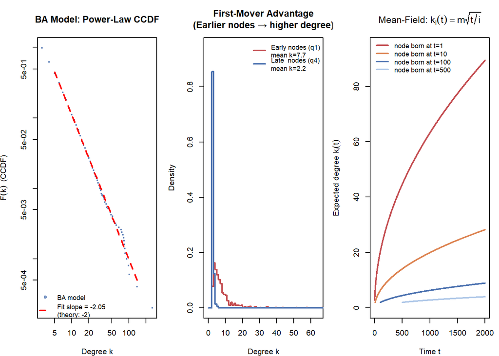

Barabási–Albert model: power-law degree distribution with γ=3, plus first-mover advantage.

```r
set.seed(42)
par(mfrow = c(1, 3), mar = c(4, 4, 4, 1))

## (A) Degree CCDF of BA model
g_ba    <- sample_pa(n = 5000, m = 3, directed = FALSE)
degs_ba <- degree(g_ba)
ks_sorted <- sort(unique(degs_ba))
ccdf_ba   <- sapply(ks_sorted, function(k) mean(degs_ba >= k))

plot(ks_sorted, ccdf_ba,
     log  = "xy", pch = 19, cex = 0.4,
     col  = adjustcolor("#4C72B0", 0.7),
     xlab = "Degree k", ylab = expression(bar(F)(k)~~"(CCDF)"),
     main = "BA Model: Power-Law CCDF")
# OLS fit on log-log scale for k in [5, 200]
mask_fit  <- ks_sorted >= 5 & ks_sorted <= 200
lm_fit    <- lm(log(ccdf_ba[mask_fit]) ~ log(ks_sorted[mask_fit]))
slope_fit <- coef(lm_fit)[2]
k_line    <- ks_sorted[mask_fit]
lines(k_line, exp(coef(lm_fit)[1]) * k_line^slope_fit,
      col = "red", lwd = 2, lty = 2)
legend("bottomleft",
       legend = c("BA model",
                  sprintf("Fit slope = %.2f\n(theory: -2)", slope_fit)),
       col    = c(adjustcolor("#4C72B0", 0.7), "red"),
       pch    = c(19, NA), lty = c(NA, 2), lwd = c(NA, 2),
       bty    = "n", cex = 0.85)

## (B) First-mover advantage
n_ba_fm  <- 2000
m_ba     <- 2
g_ba_fm  <- sample_pa(n = n_ba_fm, m = m_ba, directed = FALSE)
degs_fm  <- degree(g_ba_fm)
birth_times <- seq_len(n_ba_fm)

q25 <- quantile(birth_times, 0.25)
q75 <- quantile(birth_times, 0.75)
early <- degs_fm[birth_times <= q25]
late  <- degs_fm[birth_times >= q75]

max_d <- max(c(early, late))
h_e <- hist(early, breaks = seq(-0.5, max_d + 0.5, 1), plot = FALSE)
h_l <- hist(late,  breaks = seq(-0.5, max_d + 0.5, 1), plot = FALSE)

plot(h_e$mids, h_e$density, type = "s", col = "#C44E52", lwd = 2,
     xlab = "Degree k", ylab = "Density",
     main = "First-Mover Advantage\n(Earlier nodes → higher degree)",
     xlim = c(0, quantile(early, 0.99) * 1.5),
     ylim = c(0, max(c(h_e$density, h_l$density)) * 1.1))
lines(h_l$mids, h_l$density, type = "s", col = "#4C72B0", lwd = 2)
legend("topright",
       legend = c(sprintf("Early nodes (q1)\nmean k=%.1f", mean(early)),
                  sprintf("Late  nodes (q4)\nmean k=%.1f", mean(late))),
       col    = c("#C44E52", "#4C72B0"), lwd = 2, bty = "n", cex = 0.85)

## (C) Mean-field theory: k_i(t) = m * sqrt(t/i)
t_max   <- n_ba_fm
t_range <- seq(m_ba, t_max)

plot(NULL, xlim = c(0, t_max), ylim = c(0, m_ba * sqrt(t_max / 1) * 1.05),
     xlab = "Time t",
     ylab = expression(paste("Expected degree  ", k[i](t))),
     main = expression(paste("Mean-Field: ", k[i](t) == m * sqrt(t/i))))

born_at  <- c(1, 10, 100, 500)
mf_cols  <- c("#C44E52", "#DD8452", "#4C72B0", "#aec7e8")
for (j in seq_along(born_at)) {
  i_born  <- born_at[j]
  t_plot  <- t_range[t_range >= i_born]
  k_th    <- m_ba * sqrt(t_plot / i_born)
  lines(t_plot, k_th, col = mf_cols[j], lwd = 2)
}
legend("topleft",
       legend = paste0("node born at t=", born_at),
       col    = mf_cols, lwd = 2, bty = "n", cex = 0.85)
```

```r
cat(sprintf("BA model (n=5000, m=3): <k>=%.2f (theory 2m=%d)\n",
            mean(degs_ba), 2 * 3))
```

```
BA model (n=5000, m=3): <k>=6.00 (theory 2m=6)
```

```r
cat(sprintf("Estimated CCDF slope: %.3f (theory: -2, so γ = 3)\n", slope_fit))
```

```
Estimated CCDF slope: -2.052 (theory: -2, so γ = 3)
```

```r
cat(sprintf("\nFirst-mover advantage:\n"))
```

```
First-mover advantage:
```

```r
cat(sprintf("  Early nodes (born q1): mean degree = %.2f\n", mean(early)))
```

```
  Early nodes (born q1): mean degree = 7.66
```

```r
cat(sprintf("  Late  nodes (born q4): mean degree = %.2f\n", mean(late)))
```

```
  Late  nodes (born q4): mean degree = 2.17
```

```r
cat(sprintf("  Ratio: %.1fx\n", mean(early) / mean(late)))
```

```
  Ratio: 3.5x
```

## 5.3 The Jackson–Rogers Hybrid Model

The BA model generates power-law degree distributions but fails on:

- **Clustering**: $C \to 0$ as in ER (pure random attachment produces no triangles)
- **Degree assortativity**: BA has neutral assortativity (no correlation between a node’s degree and its neighbours’ degrees)

**Jackson & Rogers (2007, AER)** propose a two-stage attachment rule:

1. Each new node randomly meets $m_r$ existing nodes (*uniform* attachment)
2. Then explores $m_n$ additional nodes by following the *neighbours* of the first $m_r$ nodes (network search)

This generates both a (roughly) power-law degree distribution AND positive clustering (because node $i$ connects to both node $j$ and $j$’s neighbours, creating triangles). The ratio $r = m_r/m_n$ controls the trade-off:

- $r \to \infty$ (all uniform): exponential distribution, zero clustering
- $r \to 0$ (all network search): power law, positive clustering
- Intermediate $r$: interpolates; fits many real networks well

# 6 Stochastic Block Models: Networks with Community Structure

## 6.2 Model Definition

Assign each node $i$ to a group $z_i \in \{1, \ldots, k\}$. Given the group assignments, edges are drawn independently:

$$A_{ij} \sim \text{Bernoulli}(M_{z_i, z_j})$$

where $M$ is a $k \times k$ symmetric **mixing matrix** of connection probabilities.

**Special cases**: - $M_{uv} = p$ for all $u, v$: recovers Erdős–Rényi - $M_{uu} = p_{\text{in}}$, $M_{uv} = p_{\text{out}}$ for $u \neq v$: the **planted partition model**; the simplest model with community structure

## 6.3 The Planted Partition Model

Set $p = (2c + \varepsilon)/(2n)$ and $q = (2c - \varepsilon)/(2n)$. Here $c$ is the average degree, and $\varepsilon$ controls community *sharpness*:

- $\varepsilon = 0$: ER (no community signal)
- $\varepsilon \gg 0$: very distinct communities

## 6.4 MLE Inference for SBM

Given a network $G$ and assuming $k$ communities, find the group assignments $z$ and mixing matrix $M$ that maximise the likelihood. Since each pair $(i,j)$ generates a Bernoulli with parameter $M_{z_i, z_j}$:

$$\ln \mathcal{L}(G \mid z, M) = \sum_{i < j} \left[ A_{ij} \ln M_{z_i z_j} + (1 - A_{ij}) \ln(1 - M_{z_i z_j}) \right]$$

Maximising over $M$ for fixed $z$: standard Binomial MLE gives

$$\hat{M}_{uv} = \frac{E_{uv}}{N_{uv}}$$

where $E_{uv}$ = observed edges between groups $u$ and $v$, and $N_{uv}$ = total possible edges between them.

Maximising over $z$ is NP-hard in general, but greedy heuristics work well.

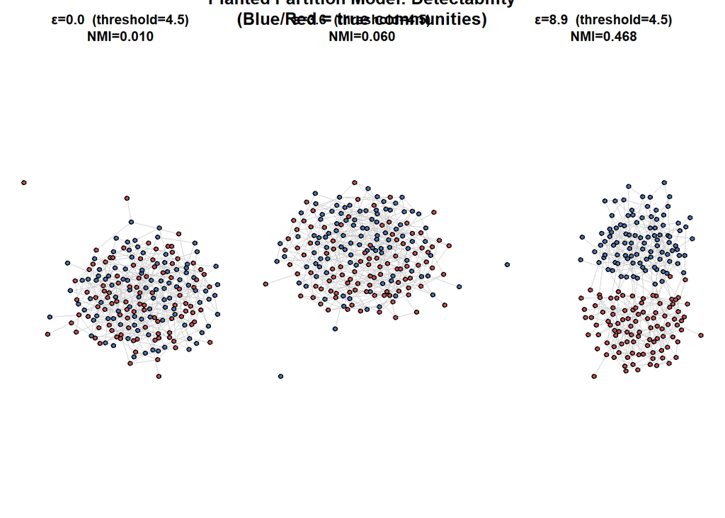

Planted partition model: varying ε around the detectability threshold.

```r
# NMI helper using base R (no sklearn dependency)
nmi_r <- function(a, b) {
  # mutual information via contingency table
  tab    <- table(a, b)
  n_obs  <- sum(tab)
  p_xy   <- tab / n_obs
  p_x    <- rowSums(p_xy)
  p_y    <- colSums(p_xy)
  # H(X), H(Y), H(X,Y)
  H_x  <- -sum(p_x[p_x > 0] * log(p_x[p_x > 0]))
  H_y  <- -sum(p_y[p_y > 0] * log(p_y[p_y > 0]))
  H_xy <- -sum(p_xy[p_xy > 0] * log(p_xy[p_xy > 0]))
  MI   <- H_x + H_y - H_xy
  if ((H_x + H_y) == 0) return(0)
  2 * MI / (H_x + H_y)
}

set.seed(42)
n_sbm   <- 200
k_sbm   <- 2
c_sbm   <- 5.0
thresh  <- 2 * sqrt(c_sbm)
eps_vec <- c(0.0, thresh * 0.8, thresh * 2.0)

par(mfrow = c(1, 3), mar = c(1, 1, 4, 1))
true_labels <- c(rep(0L, n_sbm / 2), rep(1L, n_sbm / 2))

for (eps in eps_vec) {
  p_in  <- (2 * c_sbm + eps)      / (2 * n_sbm)
  p_out <- max(0, (2 * c_sbm - eps) / (2 * n_sbm))

  pref_mat <- matrix(c(p_in, p_out, p_out, p_in), nrow = 2)
  g_sbm    <- sample_sbm(n_sbm, pref = pref_mat,
                          block.sizes = rep(n_sbm / k_sbm, k_sbm))

  # Community detection via Louvain
  mem      <- membership(cluster_louvain(g_sbm))
  nmi_val  <- nmi_r(true_labels, mem)

  v_colors <- ifelse(true_labels == 0, "#4C72B0", "#C44E52")
  set.seed(1)
  lay <- layout_with_kk(g_sbm)
  plot(g_sbm,
       layout             = lay,
       vertex.color       = v_colors,
       vertex.size        = 5,
       vertex.label       = NA,
       edge.color         = "#cccccc",
       edge.width         = 0.5,
       main               = sprintf("ε=%.1f  (threshold=%.1f)\nNMI=%.3f",
                                    eps, thresh, nmi_val))
}
mtext("Planted Partition Model: Detectability\n(Blue/Red = true communities)",
      outer = TRUE, line = -2, font = 2, cex = 1)
```

## 6.5 Degree-Corrected SBM (DC-SBM)

A known failure of the basic SBM: when the degree distribution within communities is heterogeneous, the MLE tends to group *high-degree* nodes together rather than finding true communities.

The **DC-SBM** (Karrer & Newman 2011) adds per-node *propensity parameters* $\gamma_i \geq 0$:

$$A_{ij} \sim \text{Poisson}(\gamma_i \gamma_j M_{z_i z_j})$$

The $\gamma_i$ absorbs degree heterogeneity, allowing the block structure $M$ to capture community membership without being confounded by degree. MLE gives $\hat{\gamma}_i = k_i / \kappa_{z_i}$ (node $i$’s degree as a fraction of its group’s total degree) and $\hat{M}_{uv}$ as before.

# 7 Summary and What’s Next

## 7.1 Model Comparison

```
                 Power-law degree High clustering Short paths Communities
Erdős–Rényi          No (Poisson)        No (C→0)         Yes          No
Configuration           Arbitrary        No (C→0)         Yes          No
Watts–Strogatz  No (Poisson-like)             Yes         Yes          No
Barabási–Albert         Yes (γ=3)        No (C→0)  Yes (hubs)          No
Jackson–Rogers    Yes (tunable γ)             Yes         Yes          No
SBM                  No (Poisson)    Within-block         Yes         Yes
                Tractable?
Erdős–Rényi          Fully
Configuration       Mostly
Watts–Strogatz   Numerical
Barabási–Albert Mean-field
Jackson–Rogers   Numerical
SBM                    MLE
```

## 7.2 What We Cannot Yet Answer

We have good generative models, but three big inferential questions remain:

1. **Given a real network, which model generated it?** Model selection requires likelihood comparison (BIC/AIC) or Bayesian approaches.
2. **How do we find communities in an observed network?** SBM gives us the generative story, but inference (finding $z$ from $G$) is hard computationally. This is the community detection problem; the focus of the next lecture.
3. **How do we predict missing edges or node labels?** Even with a good model, predicting new edges (link prediction) or unseen node attributes (semi-supervised classification) requires additional ML machinery.

These three questions; community detection, link prediction, node classification; are the subject of **Lecture 3: Machine Learning with Network Data**.

## 7.3 References

- Erdős, P. & Rényi, A. (1960). On the evolution of random graphs. *Publ. Math. Inst. Hung. Acad. Sci.*, 5, 17–61.
- Newman, M. E. J. (2013). *Networks: An Introduction*. Ch. 11–15.
- Watts, D. J. & Strogatz, S. H. (1998). Collective dynamics of ‘small-world’ networks. *Nature*, 393, 440–442.
- Barabási, A.-L. & Albert, R. (1999). Emergence of scaling in random networks. *Science*, 286, 509–512.
- Jackson, M. O. & Rogers, B. W. (2007). Meeting strangers and friends of friends. *American Economic Review*, 97(3), 890–915.
- Jackson, M. O. (2019). The friendship paradox and systematic biases. *Journal of Political Economy*, 127(5), 2219–2252.
- Karrer, B. & Newman, M. E. J. (2011). Stochastic blockmodels and community structure in networks. *Physical Review E*, 83, 016107.
- Decelle, A. et al. (2011). Asymptotic analysis of the stochastic block model. *Physical Review E*, 84, 066106.
- Feld, S. L. (1991). Why your friends have more friends than you do. *American Journal of Sociology*, 96(6), 1464–1477.

Back to top